# scRNA-Seq Annotation

Sara Gosline

May 29, 2018

## scRNA-Seq Immune Cell Annotation

The goal of this document is to demonstrate the basic steps/tools available to pull scRNA-seq data from [Synapse](http://www.synapse.org/scRNASeq) and use available annotations to visualize the results.

### Properly formatted data

[output not shown]

[output not shown]

All data should be in a matrix form where the rows represent genes and the columns represent samples. Please see the [scRNA-Seq Instructions](https://www.synapse.org/#!Synapse:syn11857287/wiki/518624) for more details.

```r
##here we collect project specific data

#synapse file
syn_file<-'syn12045100'

analysis_dir<-"syn12118521"

analysis_file=paste(syn_file,'analysis',sep='_')

samp.tab<-read.table(synapser::synGet(syn_file)$path,header=T)%>%select(-c(gene_id,gene_type))%>%rename(Gene=`gene_name`)

samp.tab[1:10,1:10]
```

```
##        Gene BC01_Pooled BC01_Tumor BC02_Pooled BC03_Pooled BC03LN_Pooled
## 1    TSPAN6        2.33       1.25       43.96        7.64          9.32
## 2      TNMD        0.00       0.00        0.00        0.00          0.00
## 3      DPM1       60.70      28.44       74.73       41.41         87.69
## 4     SCYL3       47.93       4.43        9.89        7.61          7.32
## 5  C1orf112        4.79       1.67       10.87        0.92         15.13
## 6       FGR        0.00       0.00        0.52        0.00          1.39
## 7       CFH        0.06       9.64        0.00        0.00          0.00
## 8     FUCA2       46.54      20.97       46.30        8.57          5.72
## 9      GCLC       11.61       5.97        8.72        5.51         10.00
## 10     NFYA        9.51       4.81       19.39        0.28         27.70
##    BC04_Pooled BC05_Pooled BC06_Pooled BC07_Tumor
## 1       133.37       84.77       48.01      60.29
## 2         0.00        0.00        0.00       1.26
## 3       120.41       70.67       92.23      32.48
## 4        12.42       12.02        7.99      27.70
## 5        17.10        5.69       29.20      17.00
## 6         2.23        0.12        2.12       8.57
## 7         3.30        0.00       45.12      50.52
## 8       130.80       64.62       17.77      20.89
## 9        14.10       21.49        3.85      15.77
## 10       27.73       13.22       19.33      26.73
```

```r
#need to remove the gene column
samp.mat<-samp.tab%>%select(-Gene)
rownames(samp.mat) <- make.names(samp.tab$Gene,unique=TRUE)

samp.mat[1:10,1:10]
```

```
##          BC01_Pooled BC01_Tumor BC02_Pooled BC03_Pooled BC03LN_Pooled
## TSPAN6          2.33       1.25       43.96        7.64          9.32
## TNMD            0.00       0.00        0.00        0.00          0.00
## DPM1           60.70      28.44       74.73       41.41         87.69
## SCYL3          47.93       4.43        9.89        7.61          7.32
## C1orf112        4.79       1.67       10.87        0.92         15.13
## FGR             0.00       0.00        0.52        0.00          1.39
## CFH             0.06       9.64        0.00        0.00          0.00
## FUCA2          46.54      20.97       46.30        8.57          5.72
## GCLC           11.61       5.97        8.72        5.51         10.00
## NFYA            9.51       4.81       19.39        0.28         27.70
##          BC04_Pooled BC05_Pooled BC06_Pooled BC07_Tumor BC07LN_Pooled
## TSPAN6        133.37       84.77       48.01      60.29         34.46
## TNMD            0.00        0.00        0.00       1.26          0.00
## DPM1          120.41       70.67       92.23      32.48         39.92
## SCYL3          12.42       12.02        7.99      27.70         22.65
## C1orf112       17.10        5.69       29.20      17.00         12.35
## FGR             2.23        0.12        2.12       8.57          0.13
## CFH             3.30        0.00       45.12      50.52          4.09
## FUCA2         130.80       64.62       17.77      20.89          8.06
## GCLC           14.10       21.49        3.85      15.77          9.24
## NFYA           27.73       13.22       19.33      26.73         38.07
```

We may also have cell-specific annotations. These two are experiment-specific and should be formatted in a way that can be better visualized. For this dataset, we have a collection of primary tumor sample, lymph nodes, bulk and single cell.

```
##               Patient IsPooled IsTumor
## BC01_Pooled      BC01     TRUE    TRUE
## BC01_Tumor       BC01    FALSE    TRUE
## BC02_Pooled      BC02     TRUE    TRUE
## BC03_Pooled      BC03     TRUE    TRUE
## BC03LN_Pooled    BC03     TRUE   FALSE
## BC04_Pooled      BC04     TRUE    TRUE
```

Now that the data are processed we can begin to cluster and annotate the cells based on gene expression levels.

### Grouping cells via clustering

The first step of analysis is to group the cells using clustering. Here we implement two approaches but can add more.

#### Plot cells in two dimensions

There are multiple ways to cluster the cells, with many more methods in development.

###### Principle Component Analysis

PCA is the simplest/fastest way, and can be done via this call.

```r
library(singleCellSeq)
#use example function
res.p<-dataMatrixToCluster.pca(samp.mat)
head(res.p)
```

```
##                      PC1          PC2
## BC01_Pooled   0.02696970 -0.084906893
## BC01_Tumor    0.03125795 -0.074773669
## BC02_Pooled   0.02662441 -0.078257021
## BC03_Pooled   0.03430636 -0.037658895
## BC03LN_Pooled 0.03869571 -0.009521593
## BC04_Pooled   0.03361522 -0.066550025
```

Hey, we have a data table with two components for each sample.

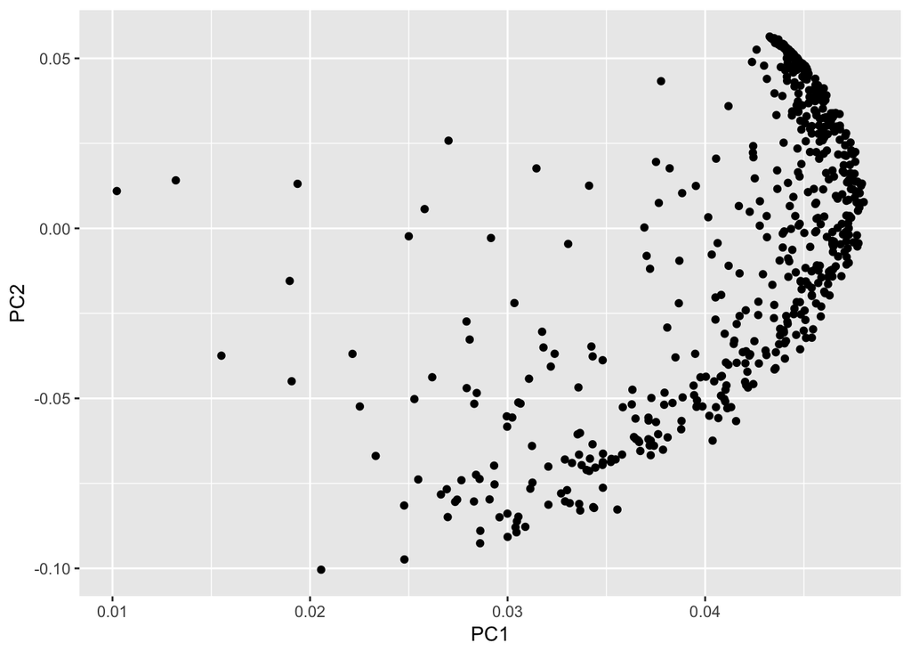

```r
library(ggplot2)
ggplot(res.p)+geom_point(aes(x=PC1,y=PC2))
```

This plots the data in one way. We can also derive clusters using T-SNE.

###### T-SNE

This takes a bit longer, and more memory.

```r
#res.t <- dataMatrixToCluster.tsne(samp.mat)
```

#### Assign cells to cluster

With these clusters we then need to group assign cells into groups.

```r
clust.pres<-dbScanPrep(res.p)
#goal is to do this for t-sne as well
#clust.tres<-dbScanPrep(res.t)
```

### single Cell Enrichment

We have also collated a set of gene lists that are known to be expressed in single cell populations.

```r
gene.annotations <- getGeneList('mcpcounter')
```

[output not shown]

```r
head(gene.annotations)
```

```
##           Gene    Cell     Source
## 1141      CD28 T cells mcpcounter
## 1142      CD3D T cells mcpcounter
## 1143      CD3G T cells mcpcounter
## 1144       CD5 T cells mcpcounter
## 1145       CD6 T cells mcpcounter
## 1146 CHRM3-AS2 T cells mcpcounter
```

Then we apply ssGSEA to these

```r
require(GSVA)
gmat<-samp.tab%>%select(-Gene)
rownames(gmat)<-make.names(samp.tab$Gene,unique=TRUE)

g.list<-lapply(gene.annotations%>%split(.$Cell),function(x) x$Gene)


g.res<-gsva(as.matrix(gmat),g.list,method='ssgsea',rnaseq=TRUE,verbose=FALSE)
g.res[1:10,1:10]
```

```
##                         BC01_Pooled BC01_Tumor BC02_Pooled BC03_Pooled
## B lineage                 0.5886067  0.6420330   0.5589646   0.9781282
## CD8 T cells               0.7034504  0.6840139   0.8907962   1.0627757
## Cytotoxic lymphocytes     0.5301188  0.5379502   0.6001512   0.6391140
## Endothelial cells         0.4624810  0.5771534   0.4675299   0.5425289
## Fibroblasts               0.5130263  0.8202621   0.6107174   0.6321474
## Monocytic lineage         0.5203332  0.7573173   0.6425303   0.6818145
## Myeloid dendritic cells   0.4617470  0.5518751   0.5367037   0.6280766
## Neutrophils               0.6480993  0.5889342   0.6082622   0.6726408
## NK cells                  0.2464482  0.4368832   0.3898419   0.4268702
## T cells                   0.6533943  0.6324681   0.6029294   0.9283101
##                         BC03LN_Pooled BC04_Pooled BC05_Pooled BC06_Pooled
## B lineage                   1.0974906   0.6914625   0.4675139   0.7852503
## CD8 T cells                 0.8883044   0.9518882   0.3118140   0.8883875
## Cytotoxic lymphocytes       0.6309806   0.7384067   0.4517303   0.5905088
## Endothelial cells           0.4816396   0.4850971   0.4774024   0.7026338
## Fibroblasts                 0.5293200   0.6359772   0.5643168   1.0281629
## Monocytic lineage           0.7930766   0.8644013   0.6614542   0.8710998
## Myeloid dendritic cells     0.7023202   0.7096731   0.4884038   0.6393011
## Neutrophils                 0.5894325   0.6357975   0.6313565   0.6411060
## NK cells                    0.2948168   0.3080448   0.2004835   0.2560509
## T cells                     0.9215864   0.8426666   0.4871763   0.6746165
##                         BC07_Tumor BC07LN_Pooled
## B lineage                0.7161669     1.0310115
## CD8 T cells              0.9843238     1.0226569
## Cytotoxic lymphocytes    0.6467070     0.7460702
## Endothelial cells        0.6830871     0.5191655
## Fibroblasts              0.9939605     0.8259104
## Monocytic lineage        0.9392929     0.8537016
## Myeloid dendritic cells  0.8168462     0.8498858
## Neutrophils              0.5918329     0.5980158
## NK cells                 0.2869478     0.4470243
## T cells                  0.7416368     0.9512864
```

Now that we have the GSEA scores for the immune sets we can plot those values and see how the cells cluster.

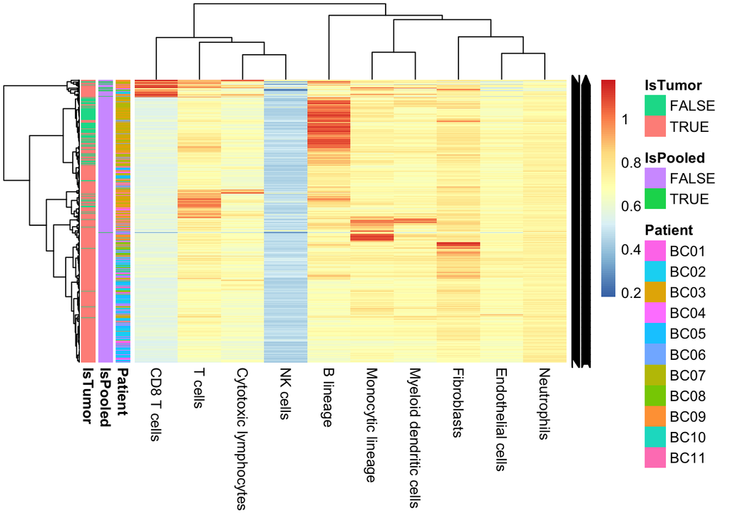